# EDA MSBA EDA

Jacob Jarrard U0082542

29 October 2023

## I. INTRO EDA for Home Credit

### Business problem statement

> Home Credit navigates the financial disparities prevalent between emerging and developed markets. As part of our ongoing commitment, the Data Analytics team is initiating an extensive risk analytics project powered by data mining techniques and best practices. Through integrating historical and real-time client data and correlating insights from specific market regions, we intend to apply predictive analytics techniques to categorize clients based on their repayment potential. We shall strategically position this project to enhance our risk modeling capabilities, facilitating a refined client acquisition process and bolstering our prominence in emerging markets.

> With that, given that the developing world needs loans but does not have a credit bureau industry established like economically developed countries, we need to draw on as many diverse data sets as possible to determine the likelihood of a given client’s repayment probability. As it is, we know a priori that only about %8 of clients have defaulted on loans to date, and %92 repay as required. Ultimately, we want to turn down loan applications to those whose data profile, in aggregate, exhibits a propensity to default. We intend to shrink the default rate of %8 to something near zero for future loan generation. We will accomplish this by identifying key variables in our datasets that show the most significant correlation to loan default or - when combined - indicate a greater likelihood of loan default.

> The following data is massive; combined training and testing data represent 356,255 observations, or individual clients past and present. The split is %86.31 (training) and %13.67 (testing). We know the disposition (default: no/yes) of those in the training data, identified as the variable “TARGET.” Upon completing the project, we intend to show how our data mining algorithm (yet undecided) will predict who of the testing data will be susceptible to default.

> We do not know when or where this data was collected, though we consider it mostly homogenous and adequate for this study. However, some data manipulation will require consideration and much work. It is worth mentioning that many people living in developing countries do not have credit histories, and the original data captured at the source was only sometimes complete, which explains most of the gaps in the data. With this in mind, despite some obvious and less obvious issues, the most significant elements that indicate default can be identified, even those that are unclear. Once captured, we can improve our data collection at the point of loan application. The following Exploratory Data Analysis hopes to, at a minimum, define the scope of the data, identify problems in the data that require deeper consideration, create a way forward according to the EDA process, and inform management of the status of the project and work that will be needed to complete it.

### Business and Analytic Problems and Approaches.

> A thorough review of the data should take into account or provide answers to the following questions:
> - How does the nature of the data in totality describe our clients in general?
> - How does the data facilitate or impede our approach to modeling and then employing our model?
> - How do the NA values affect our data modeling?
> - How are we going to consider NA values for each variable?
> - Not all the ancillary data provides information about every customer. How do we employ the ancillary data with our test/train data without increasing bias or noise?
> - The data was split 86/14 train/test. Is the testing data generally reflective of the training data?
> - The TARGET variable is ~%92 no default, ~%8 yes default. Does this affect our EDA?
> - What is our process to clean, impute, create a correlation matrix, or conduct anomaly detection on the TARGET variable?
> - What else do we need to know and have in place before we begin modeling with various algorithms?
> - Will dimensional reduction be employed given the 122 variables in the data, many of which have NA values?
> - What about feature engineering?

> The exploration of data peels back layers of detail that can spiral nearly indefinitely. The following EDA is primarily meant to understand our data, and perhaps lead us to an intermediate step of deeper exploration. For purposes of brevity the following EDA answers or raises more important questions about our data and upcoming steps.

## II. THE EDA

### 1.0 Prep the Workspace in Posit Cloud

> Start the easy work of bringing in the relevant data frames for EDA, though in this exercise we will primarily explore the main train and test data sets, with the occasional glance at the other sets. These datasets were much larger than anticipated, and I had to jack up the power of my posit cloud account to even import them in a timely fashion.

```r
main_df_train <- read.csv("application_train.csv")
main_df_test <- read.csv("application_test.csv")
#pos_cash_balance <- read.csv("POS_CASH_balance.csv")
#bureau <- read.csv("bureau.csv")
#bureau_balance <- read.csv("bureau_balance.csv")
#credit_card_balance <- read.csv("credit_card_balance.csv")
#installments_payments <- read.csv("installments_payments.csv")
#previous_application <- read.csv("previous_application.csv")
```

```r
#skim(main_df_train)
#skim(main_df_test)
#Keeping the skim function in here for future use, and opting to use the summarytools library to observe deeper summary statistics of train and test
```

### 2.0 Learning about the Training Data

> While the output is large this is really the only way to review the nature of the data from top to bottom and start the real Q&A as we dive in to its content and structure.

```r
suppressWarnings(dfSummary(main_df_train))
```

```
## Data Frame Summary
## main_df_train
## Dimensions: 307511 x 122
## Duplicates: 0
##
## -------------------------------------------------------------------------------------------------------------------------------------------
## No    Variable                       Stats / Values                    Freqs (% of Valid)       Graph                  Valid      Missing
## ----- ------------------------------ --------------------------------- ------------------------ ---------------------- ---------- ---------
## 1     SK_ID_CURR                     Mean (sd) : 278180.5 (102790.2)   307511 distinct values   : : : : : : : : : :    307511     0
##       [integer]                      min < med < max:                                           : : : : : : : : : :    (100.0%)   (0.0%)
##                                      100002 < 278202 < 456255                                   : : : : : : : : : :
##                                      IQR (CV) : 177997 (0.4)                                    : : : : : : : : : :
##                                                                                                 : : : : : : : : : :
##
## 2     TARGET                         Min  : 0                          0 : 282686 (91.9%)       IIIIIIIIIIIIIIIIII     307511     0
##       [integer]                      Mean : 0.1                        1 :  24825 ( 8.1%)       I                      (100.0%)   (0.0%)
##                                      Max  : 1
##
## 3     NAME_CONTRACT_TYPE             1. Cash loans                     278232 (90.5%)           IIIIIIIIIIIIIIIIII     307511     0
##       [character]                    2. Revolving loans                 29279 ( 9.5%)           I                      (100.0%)   (0.0%)
##
## 4     CODE_GENDER                    1. F                              202448 (65.8%)           IIIIIIIIIIIII          307511     0
##       [character]                    2. M                              105059 (34.2%)           IIIIII                 (100.0%)   (0.0%)
##                                      3. XNA                                 4 ( 0.0%)
##
## 5     FLAG_OWN_CAR                   1. N                              202924 (66.0%)           IIIIIIIIIIIII          307511     0
##       [character]                    2. Y                              104587 (34.0%)           IIIIII                 (100.0%)   (0.0%)
##
## 6     FLAG_OWN_REALTY                1. N                               94199 (30.6%)           IIIIII                 307511     0
##       [character]                    2. Y                              213312 (69.4%)           IIIIIIIIIIIII          (100.0%)   (0.0%)
##
## 7     CNT_CHILDREN                   Mean (sd) : 0.4 (0.7)             15 distinct values       :                      307511     0
##       [integer]                      min < med < max:                                           :                      (100.0%)   (0.0%)
##                                      0 < 0 < 19                                                 :
##                                      IQR (CV) : 1 (1.7)                                         :
##                                                                                                 : .
##
## 8     AMT_INCOME_TOTAL               Mean (sd) : 168797.9 (237123.1)   2548 distinct values     :                      307511     0
##       [numeric]                      min < med < max:                                           :                      (100.0%)   (0.0%)
##                                      25650 < 147150 < 1.17e+08                                  :
```

[output cut: 645 more lines]

```
##                                      IQR (CV) : 0 (3.4)                                         :
##                                                                                                 :
##
## 121   AMT_REQ_CREDIT_BUREAU_QRT      Mean (sd) : 0.3 (0.8)             11 distinct values       :                      265992     41519
##       [numeric]                      min < med < max:                                           :                      (86.5%)    (13.5%)
##                                      0 < 0 < 261                                                :
##                                      IQR (CV) : 0 (3)                                           :
##                                                                                                 :
##
## 122   AMT_REQ_CREDIT_BUREAU_YEAR     Mean (sd) : 1.9 (1.9)             25 distinct values       :                      265992     41519
##       [numeric]                      min < med < max:                                           :                      (86.5%)    (13.5%)
##                                      0 < 1 < 25                                                 :
##                                      IQR (CV) : 3 (1)                                           : :
##                                                                                                 : : .
## -------------------------------------------------------------------------------------------------------------------------------------------
```

### 2.1 Inspecting NAs for Future Action

> All the below NAs provide for hours of discussion. Moreover, the way we impute NAs here will be very important and different for each variable.

```r
# Function to identify and count NAs in variables, and also show type and ranges
identify_na_vars <- function(data) {
  na_vars <- sapply(data, function(x) any(is.na(x)))
  na_vars_names <- names(na_vars)[na_vars]
  na_counts <- sapply(data[, na_vars_names, drop = FALSE], function(x) sum(is.na(x)))
  var_types <- sapply(data[, na_vars_names, drop = FALSE], function(x) class(x)[1])

  value_ranges <- sapply(data[, na_vars_names, drop = FALSE], function(x) {
    if(is.numeric(x)) {
      # For numeric variables, return min-max range
      range_text <- paste(range(x, na.rm = TRUE), collapse = " - ")
    } else if(is.factor(x) || is.character(x)) {
      # For factor or character variables, return unique value count
      range_text <- paste(length(unique(x[!is.na(x)])), "unique values")
    } else {
      range_text <- "Unknown"
    }
    return(range_text)
  })

  if(length(na_vars_names) > 0) {
    na_data <- tibble(
      Variable = na_vars_names,
      NA_Count = na_counts,
      Var_Type = var_types,
      Value_Ranges = value_ranges
    )
    return(na_data)
  } else {
    return(tibble(
      Variable = character(),
      NA_Count = integer(),
      Var_Type = character(),
      Value_Ranges = character()
    ))
  }
}
```

```r
# Check the function on the training set
na_info_train <- identify_na_vars(main_df_train)
na_info_train
```

```
## # A tibble: 61 × 4
##    Variable                    NA_Count Var_Type Value_Ranges
##    <chr>                          <int> <chr>    <chr>
##  1 AMT_ANNUITY                       12 numeric  1615.5 - 258025.5
##  2 AMT_GOODS_PRICE                  278 numeric  40500 - 4050000
##  3 OWN_CAR_AGE                   202929 numeric  0 - 91
##  4 CNT_FAM_MEMBERS                    2 numeric  1 - 20
##  5 EXT_SOURCE_1                  173378 numeric  0.0145681324124456 - 0.9626927…
##  6 EXT_SOURCE_2                     660 numeric  8.1736165188844e-08 - 0.854999…
##  7 EXT_SOURCE_3                   60965 numeric  0.000527265238709882 - 0.89600…
##  8 APARTMENTS_AVG                156061 numeric  0 - 1
##  9 BASEMENTAREA_AVG              179943 numeric  0 - 1
## 10 YEARS_BEGINEXPLUATATION_AVG   150007 numeric  0 - 1
## # ℹ 51 more rows
```

```r
# Compare the testing set
na_info_test <- identify_na_vars(main_df_test)
na_info_test
```

```
## # A tibble: 58 × 4
##    Variable                    NA_Count Var_Type Value_Ranges
##    <chr>                          <int> <chr>    <chr>
##  1 AMT_ANNUITY                       24 numeric  2295 - 180576
##  2 OWN_CAR_AGE                    32312 numeric  0 - 74
##  3 EXT_SOURCE_1                   20532 numeric  0.0134579104986918 - 0.9391445…
##  4 EXT_SOURCE_2                       8 numeric  8.09785587553435e-06 - 0.85499…
##  5 EXT_SOURCE_3                    8668 numeric  0.000527265238709882 - 0.88253…
##  6 APARTMENTS_AVG                 23887 numeric  0 - 1
##  7 BASEMENTAREA_AVG               27641 numeric  0 - 1
##  8 YEARS_BEGINEXPLUATATION_AVG    22856 numeric  0 - 1
##  9 YEARS_BUILD_AVG                31818 numeric  0 - 1
## 10 COMMONAREA_AVG                 33495 numeric  0 - 1
## # ℹ 48 more rows
```

> Observation: Without reading too far, it occurred to me that the AMT_ANNUITY in both the training and testing data were spit very obviously 1/3 to 2/3rd and opposite what you would expect them to be given the training set was much larger than the test set. This odd detail caught my attention and made me want to dwell on NAs to observe the randomness (or lack thereof) between the two data sets.

### 2.3 Comparing NAs between Train and Test

```r
na_info_combined <- full_join(na_info_train, na_info_test, by = "Variable", suffix = c("_Train", "_Test"))
na_info_combined <- na_info_combined %>%
  select(-Var_Type_Train, -Var_Type_Test)
na_info_combined <- na_info_combined %>%
  select(Variable, NA_Count_Train, NA_Count_Test, Value_Ranges_Train, Value_Ranges_Test)

print(na_info_combined, n = 62)
```

```
## # A tibble: 61 × 5
##    Variable    NA_Count_Train NA_Count_Test Value_Ranges_Train Value_Ranges_Test
##    <chr>                <int>         <int> <chr>              <chr>
##  1 AMT_ANNUITY             12            24 1615.5 - 258025.5  2295 - 180576
##  2 AMT_GOODS_…            278            NA 40500 - 4050000    <NA>
##  3 OWN_CAR_AGE         202929         32312 0 - 91             0 - 74
##  4 CNT_FAM_ME…              2            NA 1 - 20             <NA>
##  5 EXT_SOURCE…         173378         20532 0.014568132412445… 0.01345791049869…
##  6 EXT_SOURCE…            660             8 8.1736165188844e-… 8.09785587553435…
##  7 EXT_SOURCE…          60965          8668 0.000527265238709… 0.00052726523870…
##  8 APARTMENTS…         156061         23887 0 - 1              0 - 1
##  9 BASEMENTAR…         179943         27641 0 - 1              0 - 1
## 10 YEARS_BEGI…         150007         22856 0 - 1              0 - 1
## 11 YEARS_BUIL…         204488         31818 0 - 1              0 - 1
## 12 COMMONAREA…         214865         33495 0 - 1              0 - 1
```

[output cut: 49 more lines]

> I am getting a feel for the nature of the train and test data simply from looking at the ratios of NAs in both sets (and to mull over how I would want to employ a rule to impute on any of these given variables, as I think I will have to do the same imputing of NULLs to both sets in the same manner when the time comes.)

```r
# Compare NAs a bit more

na_info_combined2 <- full_join(na_info_train, na_info_test, by = "Variable", suffix = c("_Train", "_Test"))
na_info_combined2 <- na_info_combined2 %>%
  select(-Var_Type_Train, -Var_Type_Test) %>%
  select(Variable, NA_Count_Train, NA_Count_Test, Value_Ranges_Train, Value_Ranges_Test) %>%
  mutate(
    Total_NA = NA_Count_Train + NA_Count_Test,
    Pct_NA_Train = (NA_Count_Train / Total_NA),
    Pct_NA_Test = (NA_Count_Test / Total_NA)
  )

na_info_combined2 <- na_info_combined2 %>%
  select(-NA_Count_Train, -NA_Count_Test, -Value_Ranges_Test, -Value_Ranges_Train)
print(na_info_combined2, n = 62)
```

```
## # A tibble: 61 × 4
##    Variable                     Total_NA Pct_NA_Train Pct_NA_Test
##    <chr>                           <int>        <dbl>       <dbl>
##  1 AMT_ANNUITY                        36        0.333      0.667
##  2 AMT_GOODS_PRICE                    NA       NA         NA
##  3 OWN_CAR_AGE                    235241        0.863      0.137
##  4 CNT_FAM_MEMBERS                    NA       NA         NA
##  5 EXT_SOURCE_1                   193910        0.894      0.106
##  6 EXT_SOURCE_2                      668        0.988      0.0120
##  7 EXT_SOURCE_3                    69633        0.876      0.124
##  8 APARTMENTS_AVG                 179948        0.867      0.133
##  9 BASEMENTAREA_AVG               207584        0.867      0.133
## 10 YEARS_BEGINEXPLUATATION_AVG    172863        0.868      0.132
## 11 YEARS_BUILD_AVG                236306        0.865      0.135
## 12 COMMONAREA_AVG                 248360        0.865      0.135
```

[output cut: 49 more lines]

```r
# The Skewed NA information shows that the train and test data were not split organically to begin with.
cat("Mean of Pct_NA_Train:", mean(na_info_combined2$Pct_NA_Train, na.rm = TRUE), "\n",
    "Mean of Pct_NA_Test:", mean(na_info_combined2$Pct_NA_Test, na.rm = TRUE), "\n")
```

```
## Mean of Pct_NA_Train: 0.8679185
##  Mean of Pct_NA_Test: 0.1320815
```

### 2.4 Reviewing the Test Data

```r
suppressWarnings(dfSummary(main_df_test))
```

```
## Data Frame Summary
## main_df_test
## Dimensions: 48744 x 121
## Duplicates: 0
##
## ------------------------------------------------------------------------------------------------------------------------------------------
## No    Variable                       Stats / Values                    Freqs (% of Valid)      Graph                  Valid      Missing
## ----- ------------------------------ --------------------------------- ----------------------- ---------------------- ---------- ---------
## 1     SK_ID_CURR                     Mean (sd) : 277796.7 (103169.5)   48744 distinct values   . . : . . . . . : .    48744      0
##       [integer]                      min < med < max:                                          : : : : : : : : : :    (100.0%)   (0.0%)
##                                      100001 < 277549 < 456250                                  : : : : : : : : : :
##                                      IQR (CV) : 178997.8 (0.4)                                 : : : : : : : : : :
##                                                                                                : : : : : : : : : :
##
## 2     NAME_CONTRACT_TYPE             1. Cash loans                     48305 (99.1%)           IIIIIIIIIIIIIIIIIII    48744      0
##       [character]                    2. Revolving loans                  439 ( 0.9%)                                  (100.0%)   (0.0%)
##
## 3     CODE_GENDER                    1. F                              32678 (67.0%)           IIIIIIIIIIIII          48744      0
##       [character]                    2. M                              16066 (33.0%)           IIIIII                 (100.0%)   (0.0%)
##
## 4     FLAG_OWN_CAR                   1. N                              32311 (66.3%)           IIIIIIIIIIIII          48744      0
##       [character]                    2. Y                              16433 (33.7%)           IIIIII                 (100.0%)   (0.0%)
##
## 5     FLAG_OWN_REALTY                1. N                              15086 (30.9%)           IIIIII                 48744      0
##       [character]                    2. Y                              33658 (69.1%)           IIIIIIIIIIIII          (100.0%)   (0.0%)
##
## 6     CNT_CHILDREN                   Mean (sd) : 0.4 (0.7)             11 distinct values      :                      48744      0
##       [integer]                      min < med < max:                                          :                      (100.0%)   (0.0%)
##                                      0 < 0 < 20                                                :
##                                      IQR (CV) : 1 (1.8)                                        :
##                                                                                                :
##
## 7     AMT_INCOME_TOTAL               Mean (sd) : 178431.8 (101522.6)   606 distinct values     :                      48744      0
##       [numeric]                      min < med < max:                                          :                      (100.0%)   (0.0%)
##                                      26941.5 < 157500 < 4410000                                :
##                                      IQR (CV) : 112500 (0.6)                                   :
##                                                                                                :
##
## 8     AMT_CREDIT                     Mean (sd) : 516740.4 (365397)     2937 distinct values      :                    48744      0
##       [numeric]                      min < med < max:                                          : : .                  (100.0%)   (0.0%)
```

[output cut: 617 more lines]

```
## 120   AMT_REQ_CREDIT_BUREAU_QRT      Mean (sd) : 0.5 (0.7)             0 : 23559 (55.2%)       IIIIIIIIIII            42695      6049
##       [numeric]                      min < med < max:                  1 : 15573 (36.5%)       IIIIIII                (87.6%)    (12.4%)
##                                      0 < 0 < 7                         2 :  2998 ( 7.0%)       I
##                                      IQR (CV) : 1 (1.3)                3 :   495 ( 1.2%)
##                                                                        4 :    57 ( 0.1%)
##                                                                        5 :    11 ( 0.0%)
##                                                                        6 :     1 ( 0.0%)
##                                                                        7 :     1 ( 0.0%)
##
## 121   AMT_REQ_CREDIT_BUREAU_YEAR     Mean (sd) : 2 (1.8)               16 distinct values      :                      42695      6049
##       [numeric]                      min < med < max:                                          : .                    (87.6%)    (12.4%)
##                                      0 < 2 < 17                                                : :
##                                      IQR (CV) : 3 (0.9)                                        : : .
##                                                                                                : : : .
## ------------------------------------------------------------------------------------------------------------------------------------------
```

```r
#opted to put the summary statistics of the test data here using dfSummary() from the summarytools library, though we can use the skim library as well, for a condensed output
#While much larger output, I like the summarytools output better given the task at hand.
```

### 2.5 Plotting & Observing Variability

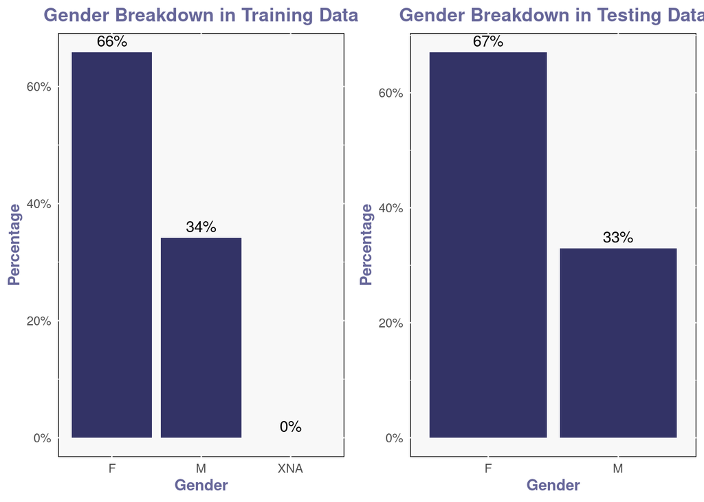

```r
# Create a function to plot gender bar plots with percentage labels
plot_gender <- function(data, title) {
  ggplot(data, aes(x = CODE_GENDER)) +
    geom_bar(aes(y = (..count..)/sum(..count..)), fill = "#333366") +
    geom_text(aes(label = scales::percent((..count..)/sum(..count..)),
                  y = ((..count..)/sum(..count..))),
              stat = "count", vjust = -0.5) +
    scale_y_continuous(labels = scales::percent) +
    labs(title = title, y = "Percentage", x = "Gender") +
    my_theme()
}

# Example usage
p1 <- plot_gender(main_df_train, "Gender Breakdown in Training Data")
p2 <- plot_gender(main_df_test, "Gender Breakdown in Testing Data")

# Print plots
grid.arrange(p1, p2, ncol=2)
```

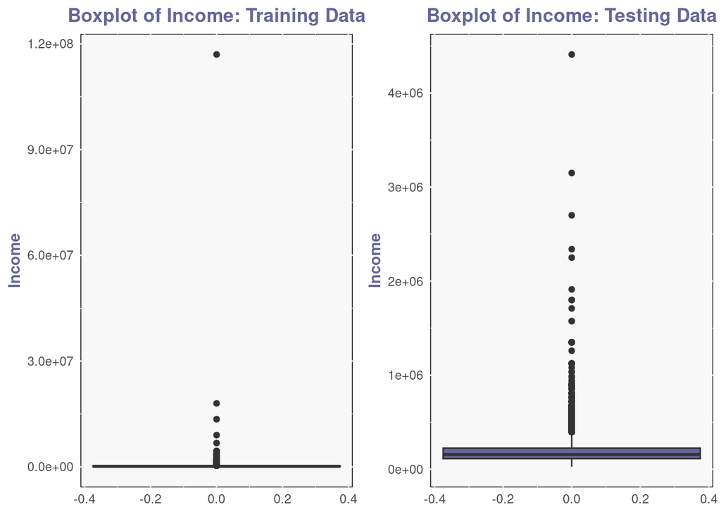

```r
#  training data
p_train <- ggplot(main_df_train, aes(y = AMT_INCOME_TOTAL)) +
  geom_boxplot(fill = "#333366") +
  labs(title = "Boxplot of Income: Training Data",
       y = "Income") +
  my_theme()

#  testing data
p_test <- ggplot(main_df_test, aes(y = AMT_INCOME_TOTAL)) +
  geom_boxplot(fill = "#666699") +
  labs(title = "Boxplot of Income: Testing Data",
       y = "Income") +
  my_theme()

# To print the plots side by side (if using RMarkdown)

grid.arrange(p_train, p_test, ncol=2)
```

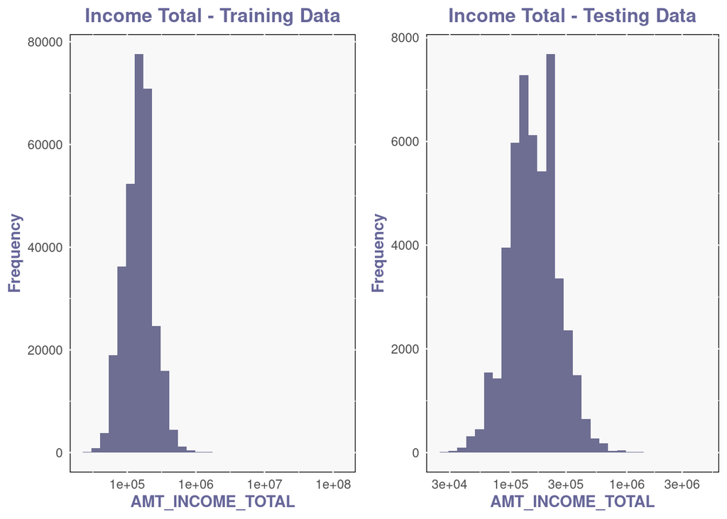

```r
plot_histogram <- function(data, var_name, title, binwidth = NULL, log_transform = FALSE) {
  p <- ggplot(data, aes_string(x = var_name)) +
    geom_histogram(
      fill = "#333366",
      bins = ifelse(is.null(binwidth), 30, NULL),
      binwidth = binwidth,
      alpha = 0.7
    ) +
    labs(title = title, x = var_name, y = "Frequency") +
    my_theme()

  # Apply log transformation to the x-axis scale if log_transform is TRUE
  if (log_transform) {
    p <- p + scale_x_continuous(trans = 'log10')
  }

  return(p)
}

# log transformed histograms ugh
p1 <- plot_histogram(main_df_train, "AMT_INCOME_TOTAL", "Income Total - Training Data", log_transform = TRUE)
p2 <- plot_histogram(main_df_test, "AMT_INCOME_TOTAL", "Income Total - Testing Data", log_transform = TRUE)


grid.arrange(p1, p2, ncol=2)
```

> I am going to quickly remove the outlier and see if it fixes the box plot or the histograms.

```r
main_df_train_no_outlier <- main_df_train %>%
  filter(AMT_INCOME_TOTAL < 4e+06)

# To verify
summary(main_df_train_no_outlier$AMT_INCOME_TOTAL) #no outlier
```

```
##    Min. 1st Qu.  Median    Mean 3rd Qu.    Max.
##   25650  112500  146812  168210  202500 3950060
```

```r
summary(main_df_train$AMT_INCOME_TOTAL) #original with outlier
```

```
##      Min.   1st Qu.    Median      Mean   3rd Qu.      Max.
##     25650    112500    147150    168798    202500 117000000
```

```r
summary(main_df_test$AMT_INCOME_TOTAL) #testing
```

```
##    Min. 1st Qu.  Median    Mean 3rd Qu.    Max.
##   26942  112500  157500  178432  225000 4410000
```

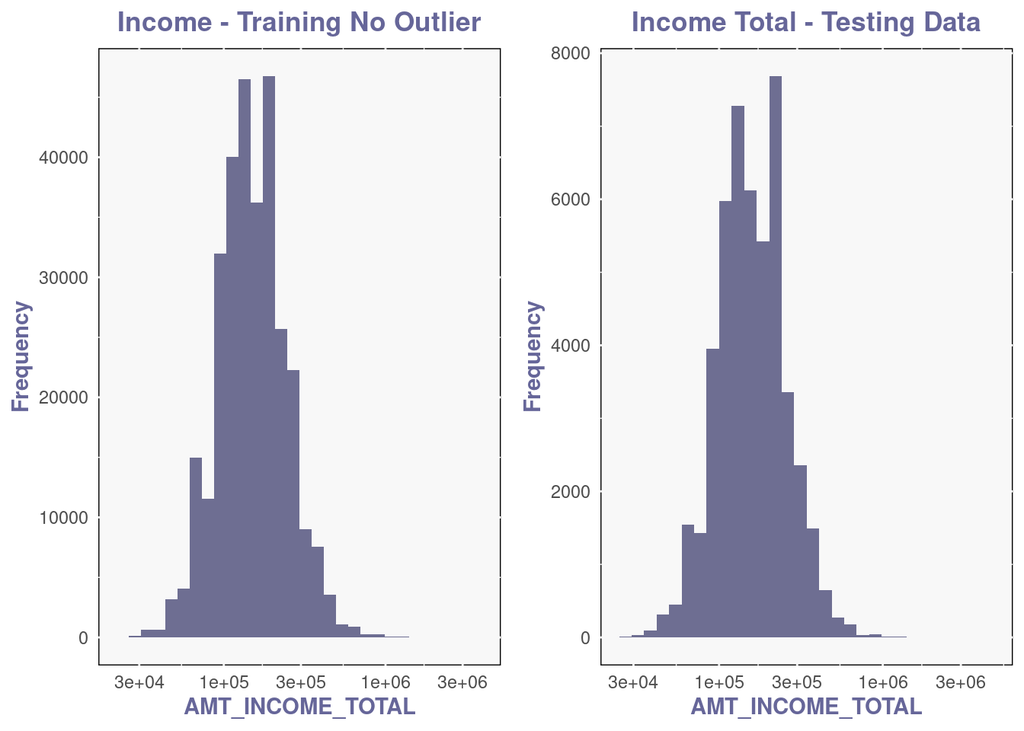

```r
p1 <- plot_histogram(main_df_train_no_outlier, "AMT_INCOME_TOTAL", "Income - Training No Outlier", log_transform = TRUE)
p2 <- plot_histogram(main_df_test, "AMT_INCOME_TOTAL", "Income Total - Testing Data", log_transform = TRUE)


grid.arrange(p1, p2, ncol=2)
```

> Removal of the outlier makes the training and testing a little more normal at this view, but…

> Box plots still show that there is some interesting variablility remaining between the training and testing sets.

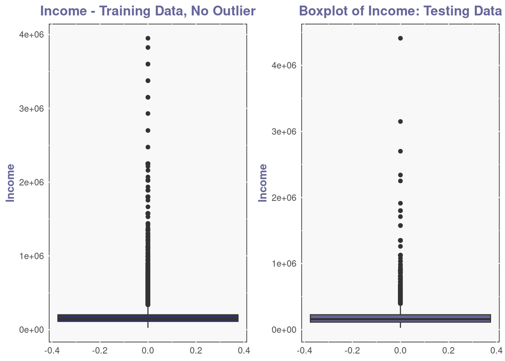

```r
# training data boxplot
p_train <- ggplot(main_df_train_no_outlier, aes(y = AMT_INCOME_TOTAL)) +
  geom_boxplot(fill = "#333366") +
  labs(title = "Income - Training Data, No Outlier",
       y = "Income") +
  my_theme()

# Create a boxplot for the testing data
p_test <- ggplot(main_df_test, aes(y = AMT_INCOME_TOTAL)) +
  geom_boxplot(fill = "#666699") +
  labs(title = "Boxplot of Income: Testing Data",
       y = "Income") +
  my_theme()

# To print the plots side by side (if using RMarkdown)

grid.arrange(p_train, p_test, ncol=2)
```

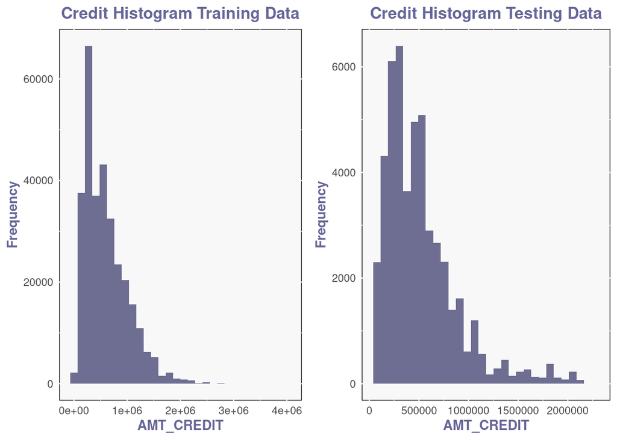

```r
p4 <- plot_histogram(main_df_train, "AMT_CREDIT", "Credit Histogram Training Data")
p5 <- plot_histogram(main_df_test, "AMT_CREDIT", "Credit Histogram Testing Data")

grid.arrange(p4, p5, ncol=2)
```

> We see some noteworthy variability in the “Amount of Annuity” between the training and testing set. The training set has a much larger spread of values, and half of the missing values of the test set. This initial and obvious issue caught my eye, and while we know the training set is roughly 7 times larger than the test set, it doesn’t yet make sense to me why these values are so different. It hints at the possibility that the data was intentionally messed with, or collected at different times or from different groups of people. (Perhaps clients captured in different marketing efforts? And then split 2/3 female and 1/3 male?)

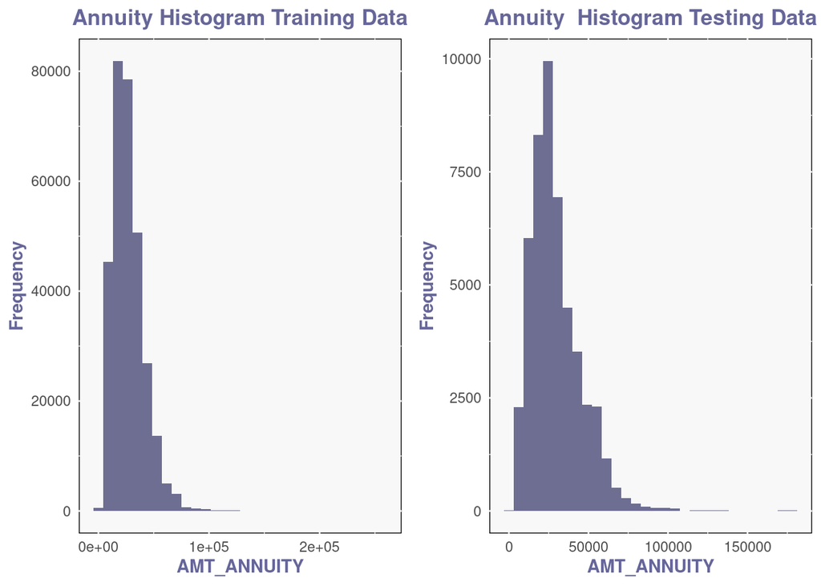

```r
p4 <- plot_histogram(main_df_train, "AMT_ANNUITY", "Annuity Histogram Training Data")
p5 <- plot_histogram(main_df_test, "AMT_ANNUITY", "Annuity  Histogram Testing Data")


grid.arrange(p4, p5, ncol=2)
```

```r
na_info_combined[1, ]
```

```
## # A tibble: 1 × 5
##   Variable    NA_Count_Train NA_Count_Test Value_Ranges_Train Value_Ranges_Test
##   <chr>                <int>         <int> <chr>              <chr>
## 1 AMT_ANNUITY             12            24 1615.5 - 258025.5  2295 - 180576
```

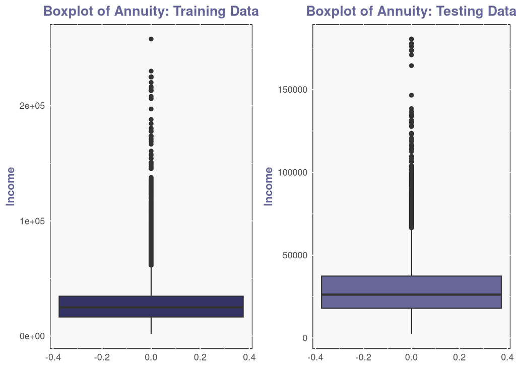

```r
#  training data
p2_train <- ggplot(main_df_train, aes(y = AMT_ANNUITY)) +
  geom_boxplot(fill = "#333366") +
  labs(title = "Boxplot of Annuity: Training Data",
       y = "Income") +
  my_theme()

#  testing data
p2_test <- ggplot(main_df_test, aes(y = AMT_ANNUITY)) +
  geom_boxplot(fill = "#666699") +
  labs(title = "Boxplot of Annuity: Testing Data",
       y = "Income") +
  my_theme()

# To print the plots side by side (if using RMarkdown)

grid.arrange(p2_train, p2_test, ncol=2)
```

### 3.0 Exploring Additional Data

> The following six datasets are related to the training and testing set and present a great deal of opportunity for inclusion as new variables into the dataset. All six data sets include client data, borrowing histories, repayment histories, and credit application inquries with reasons for denial. The way in which the values here factor into the ultimate algorithm are clearly up for debate at the moment and will be implemented after a thorough review of each.

### 3.1 bureau, bureau_balance, credit_card_balance

```r
bureau <- read.csv("bureau.csv")
bureau_balance <- read.csv("bureau_balance.csv")
credit_card_balance <- read.csv("credit_card_balance.csv")
```

```r
skim(bureau) #inspect bureau and review the number of related customer transactions
```

Data summary

| Name | bureau |
| --- | --- |
| Number of rows | 1716428 |
| Number of columns | 17 |
| _______________________ |  |
| Column type frequency: |  |
| character | 3 |
| numeric | 14 |
| ________________________ |  |
| Group variables | None |

**Variable type: character**

| skim_variable | n_missing | complete_rate | min | max | empty | n_unique | whitespace |
| --- | --- | --- | --- | --- | --- | --- | --- |
| CREDIT_ACTIVE | 0 | 1 | 4 | 8 | 0 | 4 | 0 |
| CREDIT_CURRENCY | 0 | 1 | 10 | 10 | 0 | 4 | 0 |
| CREDIT_TYPE | 0 | 1 | 8 | 44 | 0 | 15 | 0 |

**Variable type: numeric**

| skim_variable | n_missing | complete_rate | mean | sd | p0 | p25 | p50 | p75 | p100 | hist |
| --- | --- | --- | --- | --- | --- | --- | --- | --- | --- | --- |
| SK_ID_CURR | 0 | 1.00 | 278214.93 | 102938.56 | 100001.0 | 188866.8 | 278055.0 | 367426.0 | 456255 | ▇▇▇▇▇ |
| SK_ID_BUREAU | 0 | 1.00 | 5924434.49 | 532265.73 | 5000000.0 | 5463953.8 | 5926303.5 | 6385681.2 | 6843457 | ▇▇▇▇▇ |
| DAYS_CREDIT | 0 | 1.00 | -1142.11 | 795.16 | -2922.0 | -1666.0 | -987.0 | -474.0 | 0 | ▃▃▅▇▇ |
| CREDIT_DAY_OVERDUE | 0 | 1.00 | 0.82 | 36.54 | 0.0 | 0.0 | 0.0 | 0.0 | 2792 | ▇▁▁▁▁ |
| DAYS_CREDIT_ENDDATE | 105553 | 0.94 | 510.52 | 4994.22 | -42060.0 | -1138.0 | -330.0 | 474.0 | 31199 | ▁▁▇▁▁ |
| DAYS_ENDDATE_FACT | 633653 | 0.63 | -1017.44 | 714.01 | -42023.0 | -1489.0 | -897.0 | -425.0 | 0 | ▁▁▁▁▇ |
| AMT_CREDIT_MAX_OVERDUE | 1124488 | 0.34 | 3825.42 | 206031.61 | 0.0 | 0.0 | 0.0 | 0.0 | 115987185 | ▇▁▁▁▁ |
| CNT_CREDIT_PROLONG | 0 | 1.00 | 0.01 | 0.10 | 0.0 | 0.0 | 0.0 | 0.0 | 9 | ▇▁▁▁▁ |
| AMT_CREDIT_SUM | 13 | 1.00 | 354994.59 | 1149811.34 | 0.0 | 51300.0 | 125518.5 | 315000.0 | 585000000 | ▇▁▁▁▁ |
| AMT_CREDIT_SUM_DEBT | 257669 | 0.85 | 137085.12 | 677401.13 | -4705600.3 | 0.0 | 0.0 | 40153.5 | 170100000 | ▇▁▁▁▁ |
| AMT_CREDIT_SUM_LIMIT | 591780 | 0.66 | 6229.51 | 45032.03 | -586406.1 | 0.0 | 0.0 | 0.0 | 4705600 | ▇▁▁▁▁ |
| AMT_CREDIT_SUM_OVERDUE | 0 | 1.00 | 37.91 | 5937.65 | 0.0 | 0.0 | 0.0 | 0.0 | 3756681 | ▇▁▁▁▁ |
| DAYS_CREDIT_UPDATE | 0 | 1.00 | -593.75 | 720.75 | -41947.0 | -908.0 | -395.0 | -33.0 | 372 | ▁▁▁▁▇ |
| AMT_ANNUITY | 1226791 | 0.29 | 15712.76 | 325826.95 | 0.0 | 0.0 | 0.0 | 13500.0 | 118453424 | ▇▁▁▁▁ |

```r
# Knowing the number of clients in the main train/test set who appear in the bureau dataset
common_ids_bureau_train <- intersect(main_df_train$SK_ID_CURR, bureau$SK_ID_CURR)
common_ids_bureau_test <- intersect(main_df_test$SK_ID_CURR, bureau$SK_ID_CURR)
cat("Number of common SK_ID_CURR between main_df_train and bureau: ", length(common_ids_bureau_train), "\n")
```

```
## Number of common SK_ID_CURR between main_df_train and bureau:  263491
```

```r
cat("Number of common SK_ID_CURR between main_df_test and bureau: ", length(common_ids_bureau_test), "\n")
```

```
## Number of common SK_ID_CURR between main_df_test and bureau:  42320
```

```r
# I want to know the extent to which the two tables join.
```

```r
skim(bureau_balance)
```

Data summary

| Name | bureau_balance |
| --- | --- |
| Number of rows | 27299925 |
| Number of columns | 3 |
| _______________________ |  |
| Column type frequency: |  |
| character | 1 |
| numeric | 2 |
| ________________________ |  |
| Group variables | None |

**Variable type: character**

| skim_variable | n_missing | complete_rate | min | max | empty | n_unique | whitespace |
| --- | --- | --- | --- | --- | --- | --- | --- |
| STATUS | 0 | 1 | 1 | 1 | 0 | 8 | 0 |

**Variable type: numeric**

| skim_variable | n_missing | complete_rate | mean | sd | p0 | p25 | p50 | p75 | p100 | hist |
| --- | --- | --- | --- | --- | --- | --- | --- | --- | --- | --- |
| SK_ID_BUREAU | 0 | 1 | 6036297.33 | 492348.86 | 5001709 | 5730933 | 6070821 | 6431951 | 6842888 | ▃▃▇▇▆ |
| MONTHS_BALANCE | 0 | 1 | -30.74 | 23.86 | -96 | -46 | -25 | -11 | 0 | ▁▂▃▅▇ |

```r
skim(credit_card_balance)
```

Data summary

| Name | credit_card_balance |
| --- | --- |
| Number of rows | 3840312 |
| Number of columns | 23 |
| _______________________ |  |
| Column type frequency: |  |
| character | 1 |
| numeric | 22 |
| ________________________ |  |
| Group variables | None |

**Variable type: character**

| skim_variable | n_missing | complete_rate | min | max | empty | n_unique | whitespace |
| --- | --- | --- | --- | --- | --- | --- | --- |
| NAME_CONTRACT_STATUS | 0 | 1 | 6 | 13 | 0 | 7 | 0 |

**Variable type: numeric**

| skim_variable | n_missing | complete_rate | mean | sd | p0 | p25 | p50 | p75 | p100 | hist |
| --- | --- | --- | --- | --- | --- | --- | --- | --- | --- | --- |
| SK_ID_PREV | 0 | 1.00 | 1904503.59 | 536469.47 | 1000018.00 | 1434385.00 | 1897122.0 | 2369327.75 | 2843496 | ▇▇▇▇▇ |
| SK_ID_CURR | 0 | 1.00 | 278324.21 | 102704.48 | 100006.00 | 189517.00 | 278396.0 | 367580.00 | 456250 | ▇▇▇▇▇ |
| MONTHS_BALANCE | 0 | 1.00 | -34.52 | 26.67 | -96.00 | -55.00 | -28.0 | -11.00 | -1 | ▂▃▃▅▇ |
| AMT_BALANCE | 0 | 1.00 | 58300.16 | 106307.03 | -420250.18 | 0.00 | 0.0 | 89046.69 | 1505902 | ▁▇▁▁▁ |
| AMT_CREDIT_LIMIT_ACTUAL | 0 | 1.00 | 153807.96 | 165145.70 | 0.00 | 45000.00 | 112500.0 | 180000.00 | 1350000 | ▇▁▁▁▁ |
| AMT_DRAWINGS_ATM_CURRENT | 749816 | 0.80 | 5961.32 | 28225.69 | -6827.31 | 0.00 | 0.0 | 0.00 | 2115000 | ▇▁▁▁▁ |
| AMT_DRAWINGS_CURRENT | 0 | 1.00 | 7433.39 | 33846.08 | -6211.62 | 0.00 | 0.0 | 0.00 | 2287098 | ▇▁▁▁▁ |
| AMT_DRAWINGS_OTHER_CURRENT | 749816 | 0.80 | 288.17 | 8201.99 | 0.00 | 0.00 | 0.0 | 0.00 | 1529847 | ▇▁▁▁▁ |
| AMT_DRAWINGS_POS_CURRENT | 749816 | 0.80 | 2968.80 | 20796.89 | 0.00 | 0.00 | 0.0 | 0.00 | 2239274 | ▇▁▁▁▁ |
| AMT_INST_MIN_REGULARITY | 305236 | 0.92 | 3540.20 | 5600.15 | 0.00 | 0.00 | 0.0 | 6633.91 | 202882 | ▇▁▁▁▁ |
| AMT_PAYMENT_CURRENT | 767988 | 0.80 | 10280.54 | 36078.08 | 0.00 | 152.37 | 2702.7 | 9000.00 | 4289207 | ▇▁▁▁▁ |
| AMT_PAYMENT_TOTAL_CURRENT | 0 | 1.00 | 7588.86 | 32005.99 | 0.00 | 0.00 | 0.0 | 6750.00 | 4278316 | ▇▁▁▁▁ |
| AMT_RECEIVABLE_PRINCIPAL | 0 | 1.00 | 55965.88 | 102533.62 | -423305.82 | 0.00 | 0.0 | 85359.24 | 1472317 | ▁▇▁▁▁ |
| AMT_RECIVABLE | 0 | 1.00 | 58088.81 | 105965.37 | -420250.18 | 0.00 | 0.0 | 88899.49 | 1493338 | ▁▇▁▁▁ |
| AMT_TOTAL_RECEIVABLE | 0 | 1.00 | 58098.29 | 105971.80 | -420250.18 | 0.00 | 0.0 | 88914.51 | 1493338 | ▁▇▁▁▁ |
| CNT_DRAWINGS_ATM_CURRENT | 749816 | 0.80 | 0.31 | 1.10 | 0.00 | 0.00 | 0.0 | 0.00 | 51 | ▇▁▁▁▁ |
| CNT_DRAWINGS_CURRENT | 0 | 1.00 | 0.70 | 3.19 | 0.00 | 0.00 | 0.0 | 0.00 | 165 | ▇▁▁▁▁ |
| CNT_DRAWINGS_OTHER_CURRENT | 749816 | 0.80 | 0.00 | 0.08 | 0.00 | 0.00 | 0.0 | 0.00 | 12 | ▇▁▁▁▁ |
| CNT_DRAWINGS_POS_CURRENT | 749816 | 0.80 | 0.56 | 3.24 | 0.00 | 0.00 | 0.0 | 0.00 | 165 | ▇▁▁▁▁ |
| CNT_INSTALMENT_MATURE_CUM | 305236 | 0.92 | 20.83 | 20.05 | 0.00 | 4.00 | 15.0 | 32.00 | 120 | ▇▃▁▁▁ |
| SK_DPD | 0 | 1.00 | 9.28 | 97.52 | 0.00 | 0.00 | 0.0 | 0.00 | 3260 | ▇▁▁▁▁ |
| SK_DPD_DEF | 0 | 1.00 | 0.33 | 21.48 | 0.00 | 0.00 | 0.0 | 0.00 | 3260 | ▇▁▁▁▁ |

```r
common_ids_credit_train <- intersect(main_df_train$SK_ID_CURR, credit_card_balance$SK_ID_CURR)
common_ids_credit_test <- intersect(main_df_test$SK_ID_CURR, credit_card_balance$SK_ID_CURR)


cat("Number of common SK_ID_CURR between main_df_train and credit_card_balance: ", length(common_ids_credit_train), "\n")
```

```
## Number of common SK_ID_CURR between main_df_train and credit_card_balance:  86905
```

```r
cat("Number of common SK_ID_CURR between main_df_test and credit_card_balance: ", length(common_ids_credit_test), "\n")
```

```
## Number of common SK_ID_CURR between main_df_test and credit_card_balance:  16653
```

### 3.2 pos_cash_balance, installments_payments, previous_application

```r
pos_cash_balance <- read.csv("POS_CASH_balance.csv")
installments_payments <- read.csv("installments_payments.csv")
previous_application <- read.csv("previous_application.csv")
```

```r
skim(pos_cash_balance)
```

Data summary

| Name | pos_cash_balance |
| --- | --- |
| Number of rows | 10001358 |
| Number of columns | 8 |
| _______________________ |  |
| Column type frequency: |  |
| character | 1 |
| numeric | 7 |
| ________________________ |  |
| Group variables | None |

**Variable type: character**

| skim_variable | n_missing | complete_rate | min | max | empty | n_unique | whitespace |
| --- | --- | --- | --- | --- | --- | --- | --- |
| NAME_CONTRACT_STATUS | 0 | 1 | 3 | 21 | 0 | 9 | 0 |

**Variable type: numeric**

| skim_variable | n_missing | complete_rate | mean | sd | p0 | p25 | p50 | p75 | p100 | hist |
| --- | --- | --- | --- | --- | --- | --- | --- | --- | --- | --- |
| SK_ID_PREV | 0 | 1 | 1903216.60 | 535846.53 | 1000001 | 1434405 | 1896565 | 2368963 | 2843499 | ▇▇▇▇▇ |
| SK_ID_CURR | 0 | 1 | 278403.86 | 102763.75 | 100001 | 189550 | 278654 | 367429 | 456255 | ▇▇▇▇▇ |
| MONTHS_BALANCE | 0 | 1 | -35.01 | 26.07 | -96 | -54 | -28 | -13 | -1 | ▂▂▃▆▇ |
| CNT_INSTALMENT | 26071 | 1 | 17.09 | 12.00 | 1 | 10 | 12 | 24 | 92 | ▇▃▁▁▁ |
| CNT_INSTALMENT_FUTURE | 26087 | 1 | 10.48 | 11.11 | 0 | 3 | 7 | 14 | 85 | ▇▂▁▁▁ |
| SK_DPD | 0 | 1 | 11.61 | 132.71 | 0 | 0 | 0 | 0 | 4231 | ▇▁▁▁▁ |
| SK_DPD_DEF | 0 | 1 | 0.65 | 32.76 | 0 | 0 | 0 | 0 | 3595 | ▇▁▁▁▁ |

```r
common_ids_cash_balance_train <- intersect(main_df_train$SK_ID_CURR, pos_cash_balance$SK_ID_CURR)
common_ids_cash_balance_test <- intersect(main_df_test$SK_ID_CURR, pos_cash_balance$SK_ID_CURR)
cat("Number of common SK_ID_CURR between main_df_train and pos_cash_balance: ", length(common_ids_cash_balance_train), "\n")
```

```
## Number of common SK_ID_CURR between main_df_train and pos_cash_balance:  289444
```

```r
cat("Number of common SK_ID_CURR between main_df_test and pos_cash_balance: ", length(common_ids_cash_balance_test), "\n")
```

```
## Number of common SK_ID_CURR between main_df_test and pos_cash_balance:  47808
```

```r
skim(installments_payments)
```

Data summary

| Name | installments_payments |
| --- | --- |
| Number of rows | 13605401 |
| Number of columns | 8 |
| _______________________ |  |
| Column type frequency: |  |
| numeric | 8 |
| ________________________ |  |
| Group variables | None |

**Variable type: numeric**

| skim_variable | n_missing | complete_rate | mean | sd | p0 | p25 | p50 | p75 | p100 | hist |
| --- | --- | --- | --- | --- | --- | --- | --- | --- | --- | --- |
| SK_ID_PREV | 0 | 1 | 1903364.97 | 536202.91 | 1000001 | 1434191.00 | 1896520.00 | 2369094.00 | 2843499 | ▇▇▇▇▇ |
| SK_ID_CURR | 0 | 1 | 278444.88 | 102718.31 | 100001 | 189639.00 | 278685.00 | 367530.00 | 456255 | ▇▇▇▇▇ |
| NUM_INSTALMENT_VERSION | 0 | 1 | 0.86 | 1.04 | 0 | 0.00 | 1.00 | 1.00 | 178 | ▇▁▁▁▁ |
| NUM_INSTALMENT_NUMBER | 0 | 1 | 18.87 | 26.66 | 1 | 4.00 | 8.00 | 19.00 | 277 | ▇▁▁▁▁ |
| DAYS_INSTALMENT | 0 | 1 | -1042.27 | 800.95 | -2922 | -1654.00 | -818.00 | -361.00 | -1 | ▂▃▃▅▇ |
| DAYS_ENTRY_PAYMENT | 2905 | 1 | -1051.11 | 800.59 | -4921 | -1662.00 | -827.00 | -370.00 | -1 | ▁▁▂▃▇ |
| AMT_INSTALMENT | 0 | 1 | 17050.91 | 50570.25 | 0 | 4226.08 | 8884.08 | 16710.21 | 3771488 | ▇▁▁▁▁ |
| AMT_PAYMENT | 2905 | 1 | 17238.22 | 54735.78 | 0 | 3398.26 | 8125.52 | 16108.42 | 3771488 | ▇▁▁▁▁ |

```r
common_ids_installments_payments_train <- intersect(main_df_train$SK_ID_CURR, installments_payments$SK_ID_CURR)
common_ids_installments_payments_test <- intersect(main_df_test$SK_ID_CURR, installments_payments$SK_ID_CURR)
cat("Number of common SK_ID_CURR between main_df_train and installments_payments: ", length(common_ids_installments_payments_train), "\n")
```

```
## Number of common SK_ID_CURR between main_df_train and installments_payments:  291643
```

```r
cat("Number of common SK_ID_CURR between main_df_test and installments_payments: ", length(common_ids_installments_payments_test), "\n")
```

```
## Number of common SK_ID_CURR between main_df_test and installments_payments:  47944
```

```r
skim(previous_application)
```

Data summary

| Name | previous_application |
| --- | --- |
| Number of rows | 1670214 |
| Number of columns | 37 |
| _______________________ |  |
| Column type frequency: |  |
| character | 16 |
| numeric | 21 |
| ________________________ |  |
| Group variables | None |

**Variable type: character**

| skim_variable | n_missing | complete_rate | min | max | empty | n_unique | whitespace |
| --- | --- | --- | --- | --- | --- | --- | --- |
| NAME_CONTRACT_TYPE | 0 | 1 | 3 | 15 | 0 | 4 | 0 |
| WEEKDAY_APPR_PROCESS_START | 0 | 1 | 6 | 9 | 0 | 7 | 0 |
| FLAG_LAST_APPL_PER_CONTRACT | 0 | 1 | 1 | 1 | 0 | 2 | 0 |
| NAME_CASH_LOAN_PURPOSE | 0 | 1 | 3 | 32 | 0 | 25 | 0 |
| NAME_CONTRACT_STATUS | 0 | 1 | 7 | 12 | 0 | 4 | 0 |
| NAME_PAYMENT_TYPE | 0 | 1 | 3 | 41 | 0 | 4 | 0 |
| CODE_REJECT_REASON | 0 | 1 | 2 | 6 | 0 | 9 | 0 |
| NAME_TYPE_SUITE | 0 | 1 | 0 | 15 | 820405 | 8 | 0 |
| NAME_CLIENT_TYPE | 0 | 1 | 3 | 9 | 0 | 4 | 0 |
| NAME_GOODS_CATEGORY | 0 | 1 | 3 | 24 | 0 | 28 | 0 |
| NAME_PORTFOLIO | 0 | 1 | 3 | 5 | 0 | 5 | 0 |
| NAME_PRODUCT_TYPE | 0 | 1 | 3 | 7 | 0 | 3 | 0 |
| CHANNEL_TYPE | 0 | 1 | 5 | 26 | 0 | 8 | 0 |
| NAME_SELLER_INDUSTRY | 0 | 1 | 3 | 20 | 0 | 11 | 0 |
| NAME_YIELD_GROUP | 0 | 1 | 3 | 10 | 0 | 5 | 0 |
| PRODUCT_COMBINATION | 0 | 1 | 0 | 30 | 346 | 18 | 0 |

**Variable type: numeric**

| skim_variable | n_missing | complete_rate | mean | sd | p0 | p25 | p50 | p75 | p100 | hist |
| --- | --- | --- | --- | --- | --- | --- | --- | --- | --- | --- |
| SK_ID_PREV | 0 | 1.00 | 1923089.14 | 532597.96 | 1000001.00 | 1461857.25 | 1923110.50 | 2384279.75 | 2845382.0 | ▇▇▇▇▇ |
| SK_ID_CURR | 0 | 1.00 | 278357.17 | 102814.82 | 100001.00 | 189329.00 | 278714.50 | 367514.00 | 456255.0 | ▇▇▇▇▇ |
| AMT_ANNUITY | 372235 | 0.78 | 15955.12 | 14782.14 | 0.00 | 6321.78 | 11250.00 | 20658.42 | 418058.1 | ▇▁▁▁▁ |
| AMT_APPLICATION | 0 | 1.00 | 175233.86 | 292779.76 | 0.00 | 18720.00 | 71046.00 | 180360.00 | 6905160.0 | ▇▁▁▁▁ |
| AMT_CREDIT | 1 | 1.00 | 196114.02 | 318574.62 | 0.00 | 24160.50 | 80541.00 | 216418.50 | 6905160.0 | ▇▁▁▁▁ |
| AMT_DOWN_PAYMENT | 895844 | 0.46 | 6697.40 | 20921.50 | -0.90 | 0.00 | 1638.00 | 7740.00 | 3060045.0 | ▇▁▁▁▁ |
| AMT_GOODS_PRICE | 385515 | 0.77 | 227847.28 | 315396.56 | 0.00 | 50841.00 | 112320.00 | 234000.00 | 6905160.0 | ▇▁▁▁▁ |
| HOUR_APPR_PROCESS_START | 0 | 1.00 | 12.48 | 3.33 | 0.00 | 10.00 | 12.00 | 15.00 | 23.0 | ▁▃▇▆▁ |
| NFLAG_LAST_APPL_IN_DAY | 0 | 1.00 | 1.00 | 0.06 | 0.00 | 1.00 | 1.00 | 1.00 | 1.0 | ▁▁▁▁▇ |
| RATE_DOWN_PAYMENT | 895844 | 0.46 | 0.08 | 0.11 | 0.00 | 0.00 | 0.05 | 0.11 | 1.0 | ▇▁▁▁▁ |
| RATE_INTEREST_PRIMARY | 1664263 | 0.00 | 0.19 | 0.09 | 0.03 | 0.16 | 0.19 | 0.19 | 1.0 | ▇▁▁▁▁ |
| RATE_INTEREST_PRIVILEGED | 1664263 | 0.00 | 0.77 | 0.10 | 0.37 | 0.72 | 0.84 | 0.85 | 1.0 | ▁▁▅▇▁ |
| DAYS_DECISION | 0 | 1.00 | -880.68 | 779.10 | -2922.00 | -1300.00 | -581.00 | -280.00 | -1.0 | ▂▁▂▃▇ |
| SELLERPLACE_AREA | 0 | 1.00 | 313.95 | 7127.44 | -1.00 | -1.00 | 3.00 | 82.00 | 4000000.0 | ▇▁▁▁▁ |
| CNT_PAYMENT | 372230 | 0.78 | 16.05 | 14.57 | 0.00 | 6.00 | 12.00 | 24.00 | 84.0 | ▇▂▁▁▁ |
| DAYS_FIRST_DRAWING | 673065 | 0.60 | 342209.86 | 88916.12 | -2922.00 | 365243.00 | 365243.00 | 365243.00 | 365243.0 | ▁▁▁▁▇ |
| DAYS_FIRST_DUE | 673065 | 0.60 | 13826.27 | 72444.87 | -2892.00 | -1628.00 | -831.00 | -411.00 | 365243.0 | ▇▁▁▁▁ |
| DAYS_LAST_DUE_1ST_VERSION | 673065 | 0.60 | 33767.77 | 106857.03 | -2801.00 | -1242.00 | -361.00 | 129.00 | 365243.0 | ▇▁▁▁▁ |
| DAYS_LAST_DUE | 673065 | 0.60 | 76582.40 | 149647.42 | -2889.00 | -1314.00 | -537.00 | -74.00 | 365243.0 | ▇▁▁▁▂ |
| DAYS_TERMINATION | 673065 | 0.60 | 81992.34 | 153303.52 | -2874.00 | -1270.00 | -499.00 | -44.00 | 365243.0 | ▇▁▁▁▂ |
| NFLAG_INSURED_ON_APPROVAL | 673065 | 0.60 | 0.33 | 0.47 | 0.00 | 0.00 | 0.00 | 1.00 | 1.0 | ▇▁▁▁▃ |

```r
common_ids_previous_application_train <- intersect(main_df_train$SK_ID_CURR, previous_application$SK_ID_CURR)
common_ids_previous_application_test <- intersect(main_df_test$SK_ID_CURR, previous_application$SK_ID_CURR)
cat("Number of common SK_ID_CURR between main_df_train and previous_application: ", length(common_ids_previous_application_train), "\n")
```

```
## Number of common SK_ID_CURR between main_df_train and previous_application:  291057
```

```r
cat("Number of common SK_ID_CURR between main_df_test and previous_application: ", length(common_ids_previous_application_test), "\n")
```

```
## Number of common SK_ID_CURR between main_df_test and previous_application:  47800
```

### 4.0 TARGET Variable at a Glance

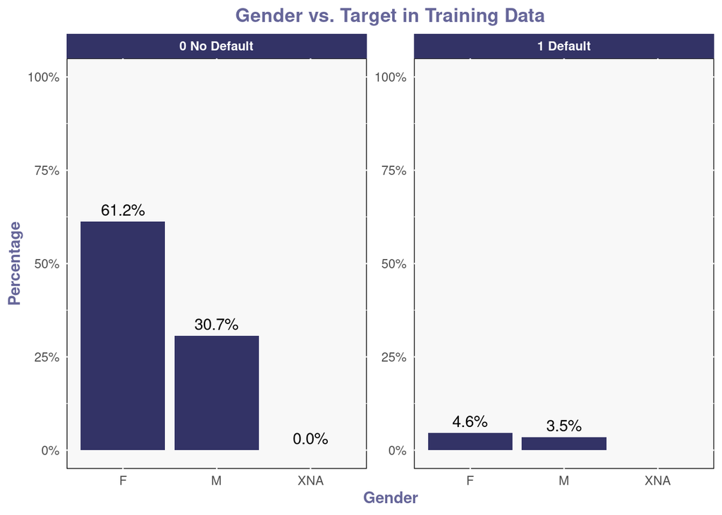

```r
# Create a function to plot gender bar plots with percentage labels
plot_target_vs_gender <- function(data, title) {
  ggplot(data, aes(x = CODE_GENDER)) +
    geom_bar(aes(y = (..count..)/sum(..count..)), fill = "#333366") +
    geom_text(aes(label = scales::percent((..count..)/sum(..count..)),
                  y = ((..count..)/sum(..count..))),
              stat = "count", vjust = -0.5) +
    scale_y_continuous(labels = scales::percent, limits = c(0, 1)) +  # Adjust y-axis limits for space
    labs(title = title, y = "Percentage", x = "Gender") +
    facet_wrap(~ TARGET, scales = "free_y",
               labeller = labeller(TARGET = c(`0` = "0 No Default", `1` = "1 Default"))) +
    # Use labeller to customize facet labels
    my_theme()
}

# Example usage
p1 <- plot_target_vs_gender(main_df_train, "Gender vs. Target in Training Data")

# Print plot
print(p1)
```

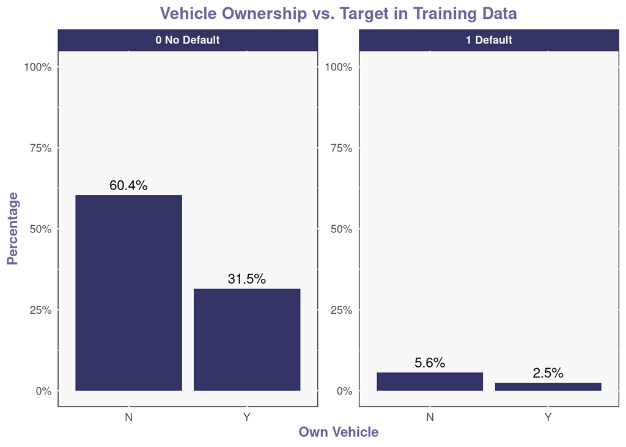

```r
# Create a function to plot gender bar plots with percentage labels
plot_target_vs_vehicle <- function(data, title) {
  ggplot(data, aes(x = FLAG_OWN_CAR)) +
    geom_bar(aes(y = (..count..)/sum(..count..)), fill = "#333366") +
    geom_text(aes(label = scales::percent((..count..)/sum(..count..)),
                  y = ((..count..)/sum(..count..))),
              stat = "count", vjust = -0.5) +
    scale_y_continuous(labels = scales::percent, limits = c(0, 1)) +  # Adjust y-axis limits for space
    labs(title = title, y = "Percentage", x = "Own Vehicle") +
    facet_wrap(~ TARGET, scales = "free_y",
               labeller = labeller(TARGET = c(`0` = "0 No Default", `1` = "1 Default"))) +
    # Use labeller to customize facet labels
    my_theme()
}

# Example usage
p2 <- plot_target_vs_vehicle(main_df_train, "Vehicle Ownership vs. Target in Training Data")

# Print plot
print(p2)
```

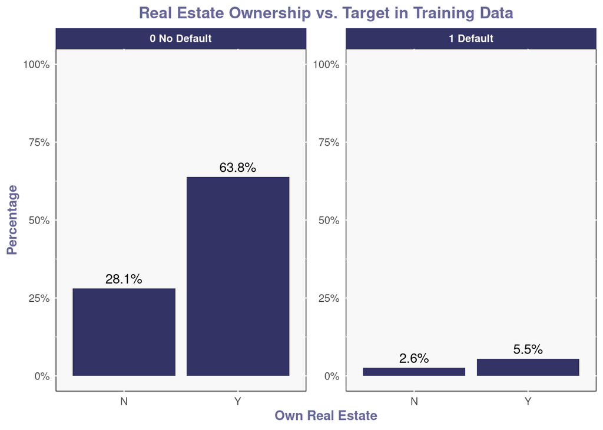

```r
# Create a function to plot gender bar plots with percentage labels
plot_target_vs_realty <- function(data, title) {
  ggplot(data, aes(x = FLAG_OWN_REALTY)) +
    geom_bar(aes(y = (..count..)/sum(..count..)), fill = "#333366") +
    geom_text(aes(label = scales::percent((..count..)/sum(..count..)),
                  y = ((..count..)/sum(..count..))),
              stat = "count", vjust = -0.5) +
    scale_y_continuous(labels = scales::percent, limits = c(0, 1)) +  # Adjust y-axis limits for space
    labs(title = title, y = "Percentage", x = "Own Real Estate") +
    facet_wrap(~ TARGET, scales = "free_y",
               labeller = labeller(TARGET = c(`0` = "0 No Default", `1` = "1 Default"))) +
    # Use labeller to customize facet labels
    my_theme()
}

# Example usage
p3 <- plot_target_vs_realty(main_df_train, "Real Estate Ownership vs. Target in Training Data")

# Print plot
print(p3)
```

> The above graphs effectively give tiny hints at how variables can have an influence on the Target variable. We can create graphs of each variable and their impact to the Target variable all day, but such effort would be best served using a linear regression model, classification tree, or a Naive Bayes model to know all the basic probabilities of the variables related to the Target. Much more analysis of this data is required before a final model is employed. Nonetheless some features of the data are more impactful than others, and some cause a great deal of noise.

## III. CONCLUSION

> Given time constraints, we provide the following insights, though note there could be infinite details extrapolated from EDA.

> The data provided was collected across a very diverse group of individuals, perhaps at different times of years, through different marketing campaigns, or from people of different geographic regions, perhaps rural or urban. We can tell that the data seems to be split intentionally, based on some unknown variable or aspect of a variable, as there are some discrepancies between the training set and testing set that are not consistent with a purely randomized split. This in-and-of-itself is not too critical as any good model should produce good predictions, but it leads me to consider the semi haphazard handling of the data and the overall integrity of the collection. That said, it is what it is, and this leads us to think harder about our next steps and what else we need to uncover before employing a model and submitting our predictions on the test data. And obviously the body of data split 66/33 female to male indicates that from the beginning the loans that were given out were unevenly distributed to women (or again, the data was intentionally manipulated.)

> Imputing data with NA values is going to be laborious and intentional. Some may be easier to impute, as in housing data, where 1 or 0 would suffice and could be largely assumed from other values. However, other variables will warrant heavy discussion with the team. Outliers do not appear to be a significant issue, and can be handled at model execution using a log function to pull in any siginificant issues.

> We will have to run some models on the anciliary data sets to find variables of significance that may not be included in the training and testing data. This is going to be a massive chore and will take all the work of the team to get correct.

> We did not include more robust correlations in this EDA but in gathering our findings, we conducted some correlation matrices that showed several categorical variables were very related, and we saw limited effects of independent variables on our target variable, but without extraordinarily profound effect up front (as in the case of the graphs exploring the target variable.) Since we have so many variables, we simply have to run a number of linear regressions and experiment with variables together to find a more profound impact on the target variable. Dimensionality reduction will be key to improving our outcomes as will finding the perfect algorithm.